# QK Box 11.1

Stokes et al. (2014) studied the neurotoxin tetrodotoxin (TTX) in flatworms. The between-plots factor was flatworm species (fixed with two groups: *Bipalium adventitium* and *Bipalium kewense*) with individual flatworms (plots) nested within species. The within-plots factor was body segment (fixed with three groups: head, anterior body, posterior body) and each segment represented a “sub-plot”. The response variable was the TTX concentration of tissue adjusted for weight. The main research questions were about the fixed effects of species, body segment and their interaction on TTX concentration, but the analyses also provide information about the variances associated with the random effects of individual within species and the random interaction between individuals within species and body segment.

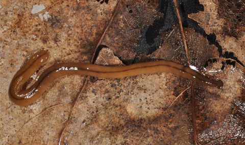

*Bipalium advenitium*. Yale Peabody Museum, , via Wikimedia Commons

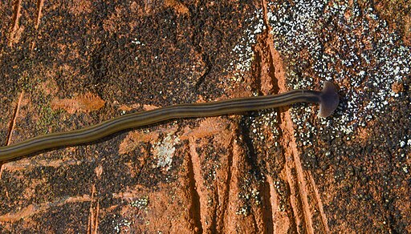

*Bipalium kewense*. Don Loarie , via Wikimedia Commons

The data are [here](https://doi.org/10.1371/journal.pone.0100718)

Stokes, A. N., Ducey, P. K., Neuman-Lee, L., Hanifin, C. T., French, S. S., Pfrender, M. E., Brodie, E. D., 3rd & Brodie, E. D., Jr. (2014). Confirmation and distribution of tetrodotoxin for the first time in terrestrial invertebrates: two terrestrial flatworm species (*Bipalium adventitium* and *Bipalium kewense*). *PLoS One*, 9, e100718.

### Preliminaries

First, load the required packages (afex, car, lattice, lme4, lmerTest, nlme, VCA, ez, emmeans) and, for convenience, apaTables

Import stokes data file (stokes.csv)

```r
stokes <- read.csv("../data/stokes.csv")
head(stokes,10)
```

|  | indiv | species | segment | finalttx | ttxweight | conc |
| --- | --- | --- | --- | --- | --- | --- |
| 1 | 1 | Badventitium | h | 59.94213 | 29.9710652 | 78.86305 |
| 2 | 1 | Badventitium | p | 18.33058 | 0.2235437 | 26.84862 |
| 3 | 1 | Badventitium | b | 36.83753 | 0.6351298 | 49.98230 |
| 4 | 2 | Badventitium | h | 62.03382 | 62.0338250 | 81.47767 |
| 5 | 2 | Badventitium | p | 46.97613 | 0.6263484 | 62.65555 |
| 6 | 2 | Badventitium | b | 61.31648 | 0.9433305 | 80.58099 |
| 7 | 3 | Badventitium | h | 29.10444 | 14.5522198 | 41.90968 |
| 8 | 3 | Badventitium | p | 50.88220 | 1.8845258 | 69.13188 |
| 9 | 3 | Badventitium | b | 66.45413 | 4.7467237 | 88.59680 |
| 10 | 4 | Badventitium | h | 46.06497 | 23.0324829 | 63.11034 |

Set contrasts from afex make individual a factor, make sure species a factor too put segments into sensible order

```r
set_sum_contrasts()
```

```
## setting contr.sum globally: options(contrasts=c('contr.sum', 'contr.poly'))
```

```r
stokes$indiv <- factor(stokes$indiv)
stokes$species<-factor(stokes$species)
stokes$segment <- factor(stokes$segment, levels=c("h","b","p"))
```

Check residuals by leaving out error term

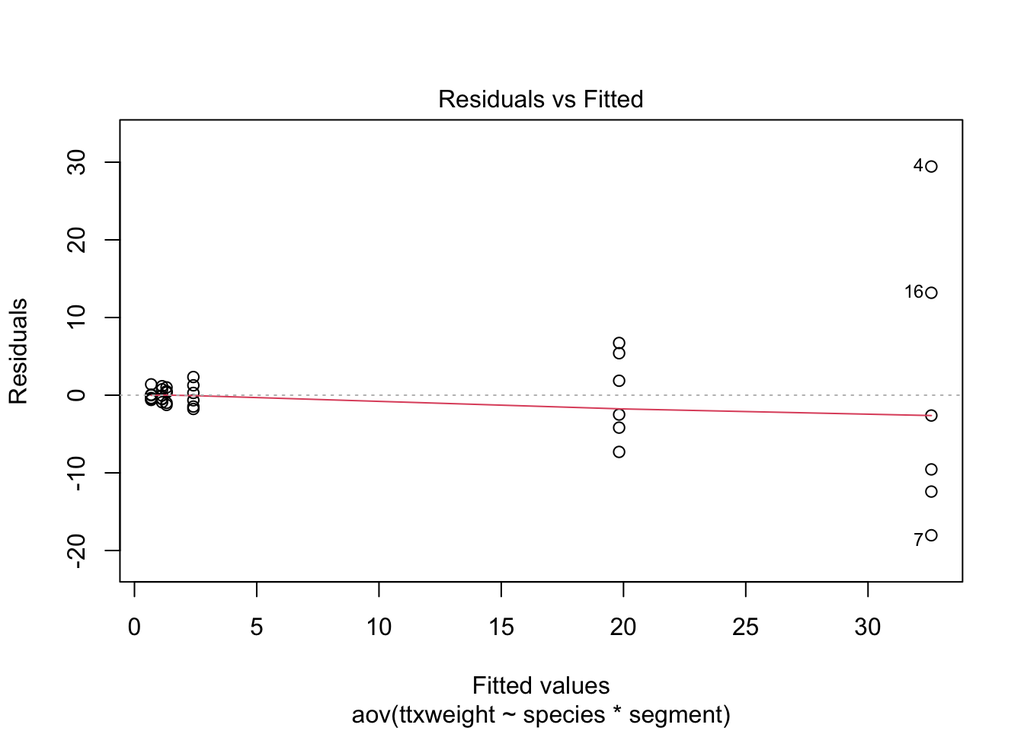

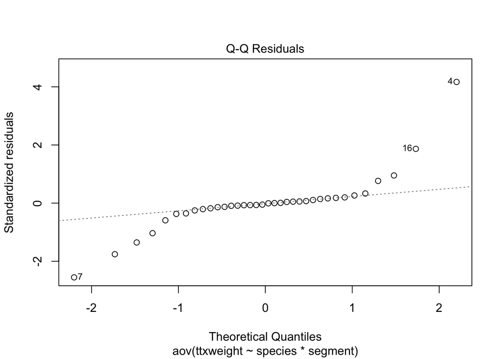

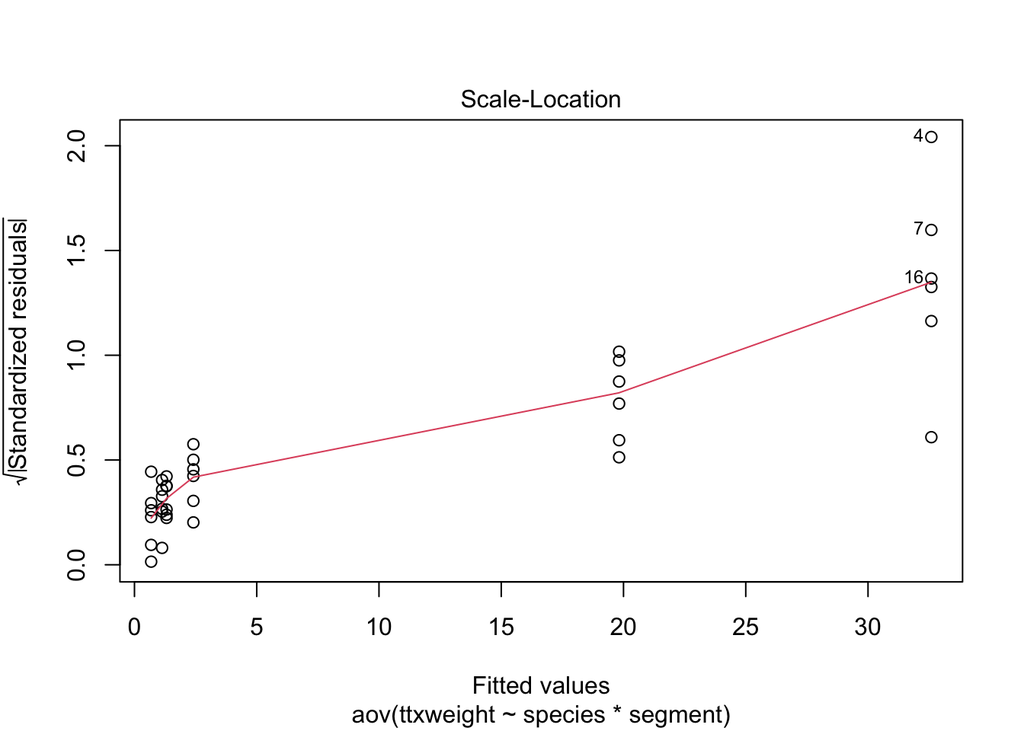

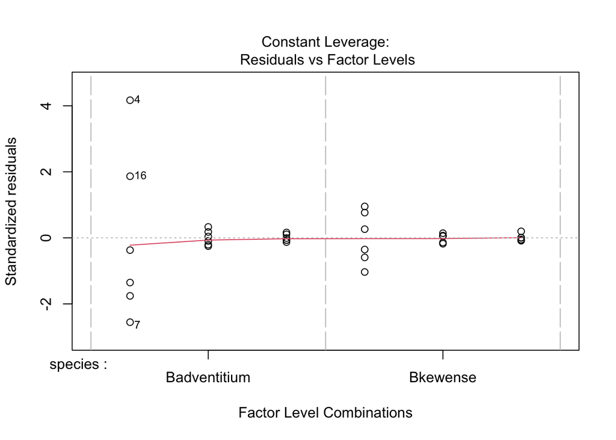

```r
stokes1.aov <- aov(ttxweight~species*segment, stokes)
plot(stokes1.aov)
```

Wedge-shaped with mean-variance relationship - redo after log transform

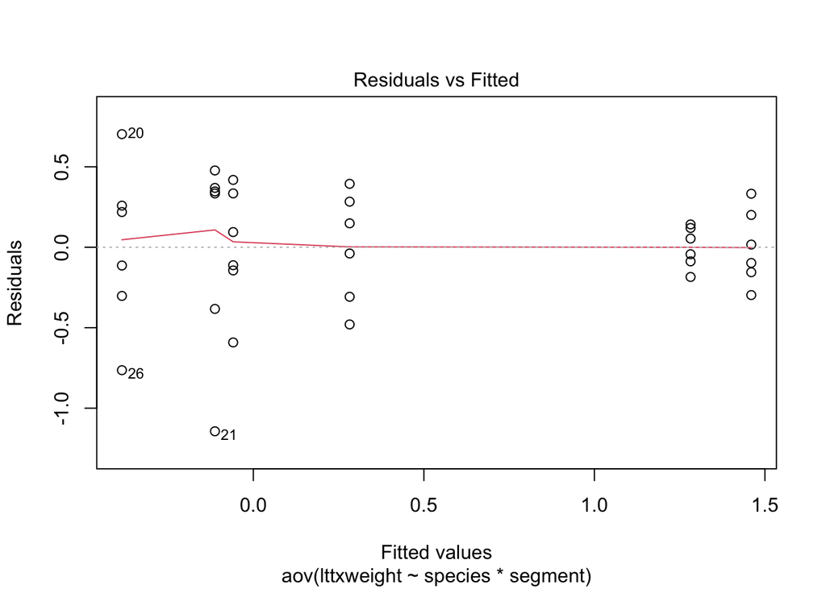

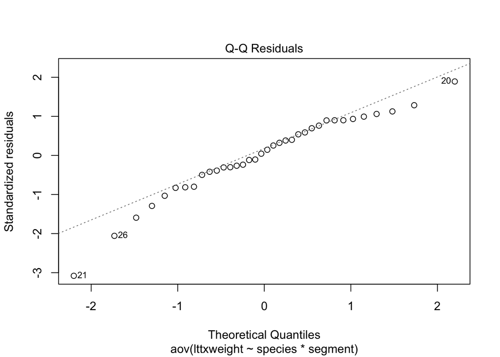

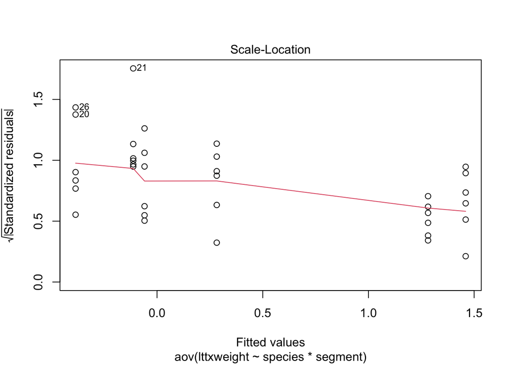

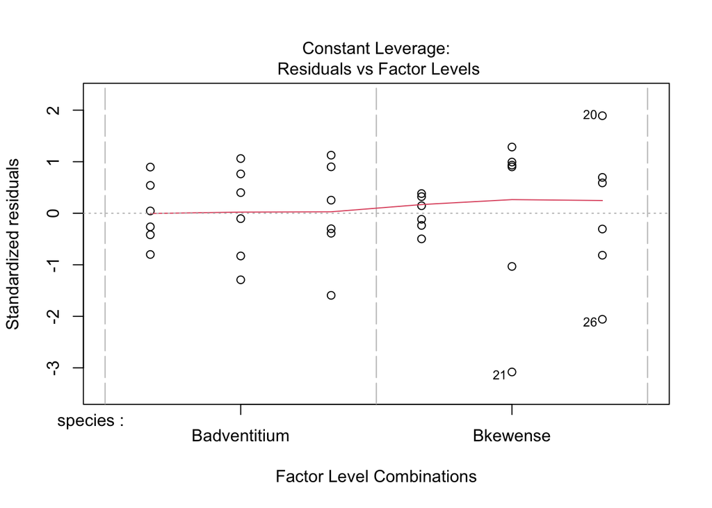

```r
stokes$lttxweight <- log10(stokes$ttxweight)
stokes2.aov <- aov(lttxweight~species*segment, stokes)
plot(stokes2.aov)
```

## Fit full model with log(ttxweight)

```r
stokes3.aov <- aov(lttxweight~species*segment+Error(indiv), stokes)
summary(stokes3.aov)
```

```
##
## Error: indiv
##           Df Sum Sq Mean Sq F value Pr(>F)
## species    1 0.8087  0.8087    6.17 0.0323 *
## Residuals 10 1.3107  0.1311
## ---
## Signif. codes:  0 '***' 0.001 '**' 0.01 '*' 0.05 '.' 0.1 ' ' 1
##
## Error: Within
##                 Df Sum Sq Mean Sq F value   Pr(>F)
## segment          2 17.149   8.575  46.965 2.78e-08 ***
## species:segment  2  0.074   0.037   0.202    0.819
## Residuals       20  3.652   0.183
## ---
## Signif. codes:  0 '***' 0.001 '**' 0.01 '*' 0.05 '.' 0.1 ' ' 1
```

Use ez for comparison with type 3 SS - same result as design is balanced

```r
ezstokes <- ezANOVA(data=stokes, dv=lttxweight, wid=indiv, within=segment, between=species, type=3)
print(ezstokes)
```

```
## $ANOVA
##            Effect DFn DFd          F            p p<.05        ges
## 2         species   1  10  6.1699328 3.232426e-02     * 0.14012958
## 3         segment   2  20 46.9649253 2.779231e-08     * 0.77558408
## 4 species:segment   2  20  0.2021994 8.185815e-01       0.01466111
##
## $`Mauchly's Test for Sphericity`
##            Effect        W         p p<.05
## 3         segment 0.719343 0.2270974
## 4 species:segment 0.719343 0.2270974
##
## $`Sphericity Corrections`
##            Effect       GGe        p[GG] p[GG]<.05       HFe        p[HF]
## 3         segment 0.7808492 6.940839e-07         * 0.8993921 1.214771e-07
## 4 species:segment 0.7808492 7.654586e-01           0.8993921 7.963230e-01
##   p[HF]<.05
## 3         *
## 4
```

### Get var components using OLS

**Note** that these estimates treat B(A)*C as the residual for B(A) vc

```r
stokes.vca <- anovaMM(lttxweight~species/(indiv)+segment+species*segment, NegVC=TRUE, stokes)
stokes.vca
```

```
##
##
## ANOVA-Type Estimation of Mixed Model:
## --------------------------------------
##
##  [Fixed Effects]
##
##                          int          speciesBadventitium
##                    -0.385414                     0.326190
##              speciesBkewense                     segmentb
##                     0.000000                     0.272682
##                     segmenth                     segmentp
##                     1.667431                     0.000000
## speciesBadventitium:segmentb     speciesBkewense:segmentb
##                     0.068888                     0.000000
## speciesBadventitium:segmenth     speciesBkewense:segmenth
##                    -0.148197                     0.000000
## speciesBadventitium:segmentp     speciesBkewense:segmentp
##                     0.000000                     0.000000
##
##
##  [Variance Components]
##
##   Name          DF        SS       MS       VC       %Total     SD
## 1 total         29.367096                   0.165407 100        0.406702
## 2 species:indiv 10        1.310664 0.131066 -0.01717 -10.380622 0
## 3 error         20        3.651543 0.182577 0.182577 110.380622 0.42729
##   CV[%]
## 1 98.914014
## 2 0
## 3 103.921222
##
## Mean: 0.411168 (N = 36)
##
## Experimental Design: balanced  |  Method: ANOVA
```

```r
VCAinference(stokes.vca, alpha=0.05, ci.method="satterthwaite")
```

```
##
##
##
## Inference from Mixed Model Fit
## ------------------------------
##
## > VCA Result:
## -------------
##
##  [Fixed Effects]
##
##                          int          speciesBadventitium
##                      -0.3854                       0.3262
##              speciesBkewense                     segmentb
##                       0.0000                       0.2727
##                     segmenth                     segmentp
##                       1.6674                       0.0000
## speciesBadventitium:segmentb     speciesBkewense:segmentb
##                       0.0689                       0.0000
## speciesBadventitium:segmenth     speciesBkewense:segmenth
##                      -0.1482                       0.0000
## speciesBadventitium:segmentp     speciesBkewense:segmentp
##                       0.0000                       0.0000
##
##
##  [Variance Components]
##
##   Name          DF      SS     MS     VC      %Total   SD     CV[%]
## 1 total         29.3671               0.1654  100      0.4067 98.914
## 2 species:indiv 10      1.3107 0.1311 -0.0172 -10.3806 0      0
## 3 error         20      3.6515 0.1826 0.1826  110.3806 0.4273 103.9212
##
## Mean: 0.4112 (N = 36)
##
## Experimental Design: balanced  |  Method: ANOVA
##
##
## > VC:
## -----
##               Estimate      DF CI LCL CI UCL One-Sided LCL One-Sided UCL
## total           0.1654 29.3671 0.1052 0.2976        0.1130        0.2699
## species:indiv  -0.0172  0.7840
## error           0.1826 20.0000 0.1069 0.3807        0.1163        0.3365
##
## > SD:
## -----
##               Estimate      DF CI LCL CI UCL One-Sided LCL One-Sided UCL
## total           0.4067 29.3671 0.3243 0.5456        0.3361        0.5195
## species:indiv   0.0000  0.7840
## error           0.4273 20.0000 0.3269 0.6170        0.3410        0.5801
##
## > CV[%]:
## --------
##               Estimate      DF  CI LCL   CI UCL One-Sided LCL One-Sided UCL
## total          98.9140 29.3671 78.8754 132.6887       81.7401      126.3578
## species:indiv   0.0000  0.7840
## error         103.9212 20.0000 79.5059 150.0695       82.9244      141.0874
##
##
## 95% Confidence Level  |  CIs for negative VCs excluded
## Satterthwaite methodology used for computing CIs
```

## Fit mixed effects models with lmer

```r
stokes.lmer <- lmer(lttxweight~species+segment+species*segment+(1|indiv), REML=TRUE, stokes)
```

```
## boundary (singular) fit: see help('isSingular')
```

Check residuals from lmer plot

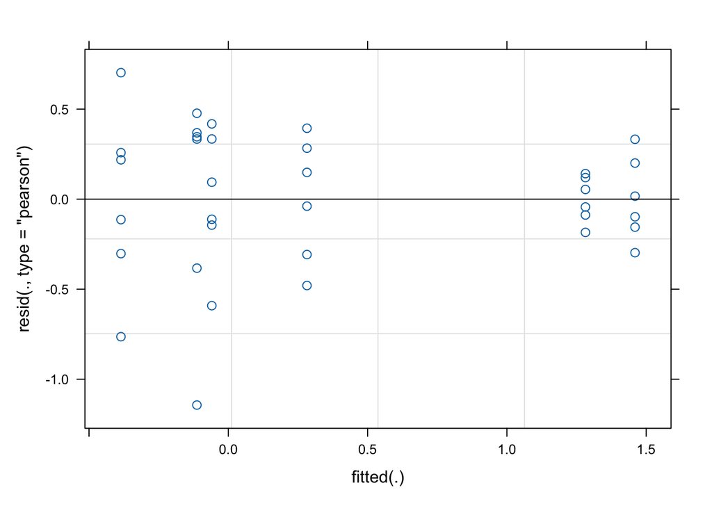

```r
plot(stokes.lmer)
```

```r
summary(stokes.lmer, ddf="Kenward-Roger")
```

```
## Linear mixed model fit by REML. t-tests use Kenward-Roger's method [
## lmerModLmerTest]
## Formula: lttxweight ~ species + segment + species * segment + (1 | indiv)
##    Data: stokes
##
## REML criterion at convergence: 50.5
##
## Scaled residuals:
##      Min       1Q   Median       3Q      Max
## -2.81144 -0.39960  0.08694  0.72676  1.72771
##
## Random effects:
##  Groups   Name        Variance Std.Dev.
##  indiv    (Intercept) 0.0000   0.0000
##  Residual             0.1654   0.4067
## Number of obs: 36, groups:  indiv, 12
##
## Fixed effects:
##                   Estimate Std. Error       df t value Pr(>|t|)
## (Intercept)        0.41117    0.06778 10.00000   6.066 0.000121 ***
## species1           0.14988    0.06778 10.00000   2.211 0.051464 .
## segment1           0.95985    0.09586 20.00000  10.013  3.1e-09 ***
## segment2          -0.32636    0.09586 20.00000  -3.405 0.002812 **
## species1:segment1 -0.06088    0.09586 20.00000  -0.635 0.532568
## species1:segment2  0.04766    0.09586 20.00000   0.497 0.624467
## ---
## Signif. codes:  0 '***' 0.001 '**' 0.01 '*' 0.05 '.' 0.1 ' ' 1
##
## Correlation of Fixed Effects:
##             (Intr) specs1 sgmnt1 sgmnt2 spc1:1
## species1     0.000
## segment1     0.000  0.000
## segment2     0.000  0.000 -0.500
## spcs1:sgmn1  0.000  0.000  0.000  0.000
## spcs1:sgmn2  0.000  0.000  0.000  0.000 -0.500
## optimizer (nloptwrap) convergence code: 0 (OK)
## boundary (singular) fit: see help('isSingular')
```

```r
anova(stokes.lmer, ddf="Kenward-Roger")
```

|  | Sum Sq | Mean Sq | NumDF | DenDF | F value | Pr(>F) |
| --- | --- | --- | --- | --- | --- | --- |
| species | 0.80867062 | 0.80867062 | 1 | 10 | 4.8889776 | 5.146443e-02 |
| segment | 17.14944570 | 8.57472285 | 2 | 20 | 51.8401767 | 1.222624e-08 |
| species:segment | 0.07383397 | 0.03691699 | 2 | 20 | 0.2231889 | 8.019294e-01 |

### Contrast head vs anterior and anterior vs posterior segments

```r
stokes.emm <- emmeans(stokes.lmer, ~segment)
```

```
## NOTE: Results may be misleading due to involvement in interactions
```

```r
stokes.con <- contrast(stokes.emm, "consec")
summary(stokes.con, adjust="none")
```

|  | contrast | estimate | SE | df | t.ratio | p.value |
| --- | --- | --- | --- | --- | --- | --- |
| 1 | b - h | -1.2862062 | 0.1660356 | 20 | -7.746569 | 1.909788e-07 |
| 2 | p - b | -0.3071264 | 0.1660356 | 20 | -1.849762 | 7.918114e-02 |

### Get variance components with CIs

```r
stokes.ci <- confint.merMod(stokes.lmer)
```

```
## Computing profile confidence intervals ...
```

```r
stokes.vc <- (stokes.ci)^2
print(stokes.vc)
```

```
##                          2.5 %     97.5 %
## .sig01            0.0000000000 0.04989851
## .sigma            0.0897577507 0.22735990
## (Intercept)       0.0821288275 0.28703247
## species1          0.0006396067 0.07533009
## segment1          0.6141142602 1.29058241
## segment2          0.2525582467 0.02255047
## species1:segment1 0.0562032225 0.01329672
## species1:segment2 0.0165198438 0.05011064
```